# Quinta entrega de Modelos Lineales

Fabricio Camacho

2024-07-11

## Ejercicio 1

**Sea Y una variable con distribución perteneciente a la familia exponencial, esto es:**

$$f_Y(y|\theta,\phi) = \exp\left( \frac{y \theta - b(\theta)}{a(\phi)} +
c(y; \phi) \right)$$

**Empleando algunas propiedades del score s(**$\theta$**) en clase se comprobó que** $E(Y) = b'(\theta)$. **Válgase de estas propiedades para demostrar el otro resultado que se planteó durante la clase, esto es:**

$$\text{Var}(Y) = b''(\theta) a(\phi)$$

**Se pide:**

**1) Demuestre este resultado.**

**2) Utilice estas propiedades para obtener la esperanza y Varianza de la dsitribución Poisson.**

**3) Utilice estas propiedades para obtener la esperanza y Varianza de la dsitribución Bernoulli.**

**1)**

Definimos la función score($\theta$) como la derivada respecto de $\theta$ del logarítmo de la densidad $f_Y(y|\theta , \phi)$

$$s(\theta) = \frac{\partial (\log ((y \theta - b(\theta)))}{\partial
\theta} =\frac{\partial}{\partial \theta} \left( \frac{a(\phi)(y\theta -
b(\theta))}{a(\phi)} + c(y; \phi) \right) = \frac {y - b'(\theta)}
{a(\phi)}$$

Luego como:

$$E \left(\frac {y - b'(\theta)}
{a(\phi)} \right) = \frac{E(y)-b'(\theta)} {a(\phi)} =
\frac{\mu-b'(\theta)}{a(\phi)} = 0$$

Tenemos que:

$$b'(\theta) = \mu = E(Y)$$

Para la varianza de la función $s(\theta)$:

$$\text{Var}(s(\theta)) = E[s(\theta)^2] - (E[s(\theta)])^2
= E\left[\left( \frac {y - b'(\theta)} {a(\phi)} \right)^2\right] -
0 = \frac {Var(Y)}{a(\phi)^2}$$

Dado que $Var(Y) = E(Y)^2-E(Y^2)$:

$$\text{Var}(s(\theta)) = E[s(\theta)^2]-E[s(\theta)]^2 = E(s(\theta)^2) =
E \left[\left(\frac {(y - b'(\theta))^2} {a(\phi)^2} \right)\right]=$$

$$\left(\frac {E[(y - E(y))^2]} {a(\phi)^2} \right) = \frac
{\text{Var}(Y)} {a(\phi)^2} = I(\theta)$$

Donde:

$$I(\theta) =-
E\left[\frac{\partial^2}{\partial\theta^2}logfy(y,\theta)\right] = \frac
{b''(\theta))}{a(\phi)}$$

$$I(\theta)= \frac {b''(\theta))}{a(\phi)} =\frac {\text{Var}(Y)}
{a(\phi)^2}$$

Entonces:

$$\text {Var(Y)} = {b''(\theta))}{a(\phi)}$$

**2)**

Sea una variable $Y$ con distribución $fy(y,\lambda)= \frac{\lambda^{y} e^{-\lambda}}{y!}$ :

$$fy(y,\lambda) = exp(y log (\lambda)-\lambda-log(y!))$$

dado que $\theta = log(\lambda)$, $a(\phi) = 1$, $b(\theta)= e^{\theta}$ y $c(y,\theta)=log(y!)$:

$$E[Y] = b'(\theta) =e^{\theta}= \lambda$$
$$Var(Y)= {b''(\theta))}{a(\phi)} = e^{\theta} . 1 = \lambda$$

**3)**

Sea una variable $Y$ con distribución $fy(y,p)= {p^{y}(1-p)^{1-y}}$:

$$fy(y,\theta) = exp(ylog\left(\frac{p}{1-p}\right)+log(1-p))$$

Dado que: $\theta = log\frac{p}{1-p}$, $a(\phi) = 1$, $b(\theta)= log(1+e^{\theta})$ y $c(y,\theta)=0$

$$E[Y] = b'(\theta) =\frac{e^{\theta}}{1+e^{\theta}}= p$$

$$Var(Y)= {b''(\theta))}{a(\phi)} =
\frac{e^{\theta}}{(1+e^{\theta})^2}={p}{(1-p)}$$

## Ejercicio 2

En el archivoi huracanes.xlsx se dispone de la información de 337 huracanes registrados en la zona del Atlántico norte. A partir de este conjunto de datos se pide construir un modelo de regresión logística que permita determinar si la latitud donde se crea el huracán es capaz de predecir si este será de tipo tropical o no.

Se pide:

1. Ajuste un GLM adecuado a la variable de respuesta que se indica (tropical vs no tropical).
2. Indique el poder predictivo de este modelo en base a los indicadores *pseudo*-R2 vistos en clase.
3. Interprete el valor del coeficiente asociado a la variable *Latitud de creacion* (variable lat creacion en el conjunto de datos).
4. A partir de los resultados del modelo realice un gráfico que permita visualizar la probabilidad de que un huracán sea tropical en función de su latitud de creación.

```
## here() starts at C:/Users/fabri/OneDrive/Escritorio/Cosas/Facultad/1-Modelos lineales/Modelos-Lineales
```

**1)**

```r
mod <- glm(trop2 ~ lat_creacion, data = huracanes, family = binomial) #Modelo
```

**2)**

```r
Mcfaden <- 1 - (mod$deviance / mod$null.deviance)

cat("Pseudo R2=",Mcfaden)
```

```
## Pseudo R2= 0.4989746
```

**3)**

```r
summary(mod)
```

```
##
## Call:
## glm(formula = trop2 ~ lat_creacion, family = binomial, data = huracanes)
##
## Coefficients:
##              Estimate Std. Error z value Pr(>|z|)
## (Intercept)   9.08263    0.96148   9.446   <2e-16 ***
## lat_creacion -0.37283    0.03947  -9.447   <2e-16 ***
## ---
## Signif. codes:  0 '***' 0.001 '**' 0.01 '*' 0.05 '.' 0.1 ' ' 1
##
## (Dispersion parameter for binomial family taken to be 1)
##
##     Null deviance: 463.11  on 336  degrees of freedom
## Residual deviance: 232.03  on 335  degrees of freedom
## AIC: 236.03
##
## Number of Fisher Scoring iterations: 6
```

El modelo explica el **49.9%** de la varianza al explicar si el huracan es tropical o no según la latitud según *Mc Faden*

La variable explicativa *lat_creación* es significativa para el modelo con un *p-valor* < 0.001

**4)**

```r
ggplot(huracanes, aes(x = lat_creacion, y = trop2)) +
  geom_point() +
  #xlab('Latitud') +
  #ylab('Prob Tropical') +
  labs(title = "Probabilidad de que un huracán sea tropical en función de su latitud de creación",
       x = "Latitud",
       y = "Prob tropical") +
  theme_bw() -> p1
#p1

# la interpretacion de b1
betas <- coef(mod)
exp(betas[2])
```

```
## lat_creacion
##    0.6887826
```

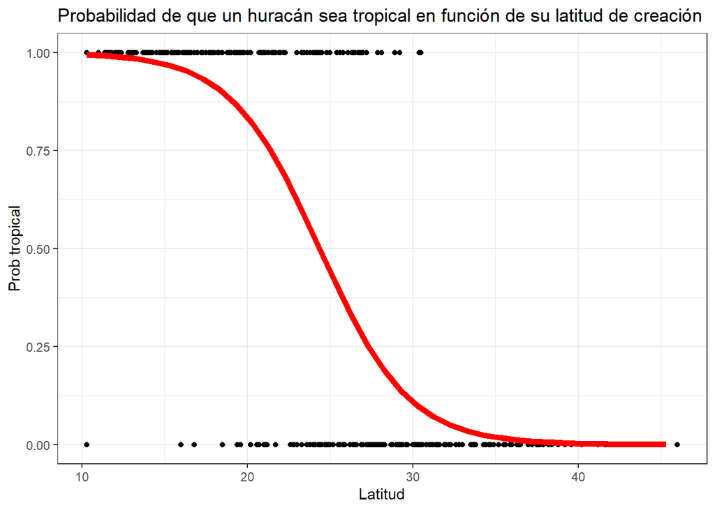

```r
xp <- min(huracanes$lat_creacion):max(huracanes$lat_creacion)
b0 <- betas[1]
b1 <- betas[2]
curva <- data.frame(lat_creacion = xp, trop2 = exp(b0 + b1*xp)/(1 +  exp(b0 + b1*xp)))

#p1 +
 # geom_line(data = curva, col = 'red', size = 2)


# grafiquemos la curva Y la recta
p1 +
  geom_line(data = curva, col = 'red', size = 2)
```

```r
 # geom_line(data = recta, col = 'blue', size = 2)
```